# Workshop 2 markdown

Andrew Stewart

3/05/2018

## Linear Mixed Models

The purpose of this workshop is to give you experience using linear mixed model (LMM) analysis.

# Q1

Within R, import the dataset w3data1. These data are from a reaction time experiment. Fifty participants had to respond to a word on the screen. Their task was to press a button on a button box only when they recognized the word (our DV is measures in milliseconds). The words were either Rare or Common. The design is repeated measures. We might expect Common words to be recognized more quickly than Rare words. Run the appropriate LMM to determine whether this is indeed correct.

First we need to make sure that our Subject, Item, and Condition columns are all factors - the first two we will use as our random effects, the third as our fixed effect:

```r
w3data1$Subject <- as.factor(w3data1$Subject)
w3data1$Item <- as.factor(w3data1$Item)
w3data1$Condition <- as.factor(w3data1$Condition)
```

Generate some descriptives and plot some data:

```r
describeBy(w3data1$RT, group=w3data1$Condition)
```

```
##
##  Descriptive statistics by group
## group: Common
##    vars   n    mean     sd median trimmed    mad min  max range skew
## X1    1 350 1369.97 658.13 1217.5 1293.62 553.75  54 4173  4119  1.2
##    kurtosis    se
## X1      1.8 35.18
## --------------------------------------------------------
## group: Rare
##    vars   n    mean     sd median trimmed   mad min  max range skew
## X1    1 349 1562.79 864.18   1403 1452.18 673.1 329 7000  6671 2.27
##    kurtosis    se
## X1     8.99 46.26
```

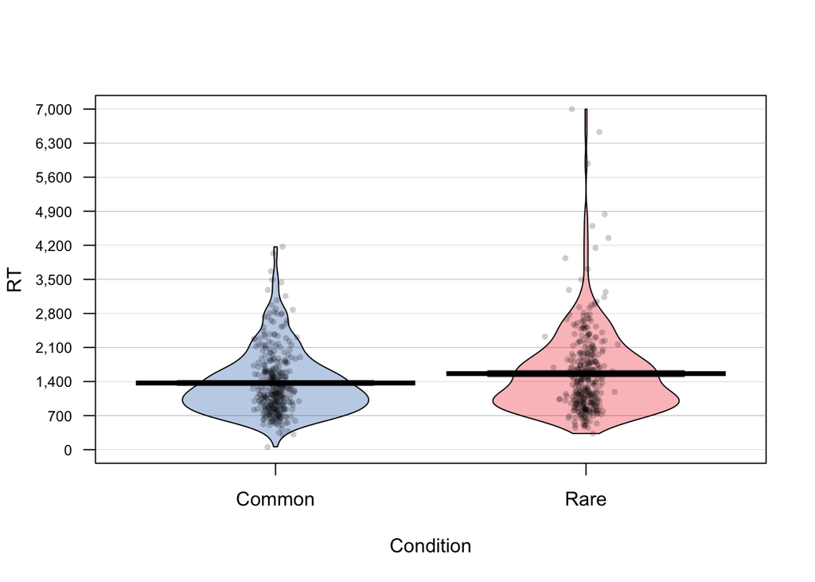

```r
pirateplot (formula=RT~Condition, data=w3data1, inf.method="se", cex.axis=.75, theme=1)
```

We can visualise our data using the vis_dat function:

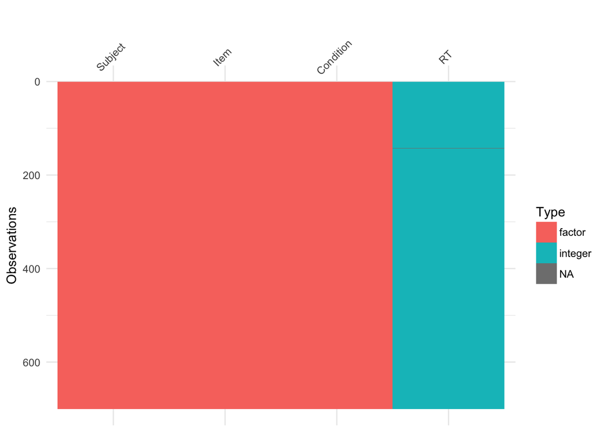

```r
vis_dat(w3data1)
```

Looks like we have one missing value. Let’s look at our RT data to check it looks relatively normal:

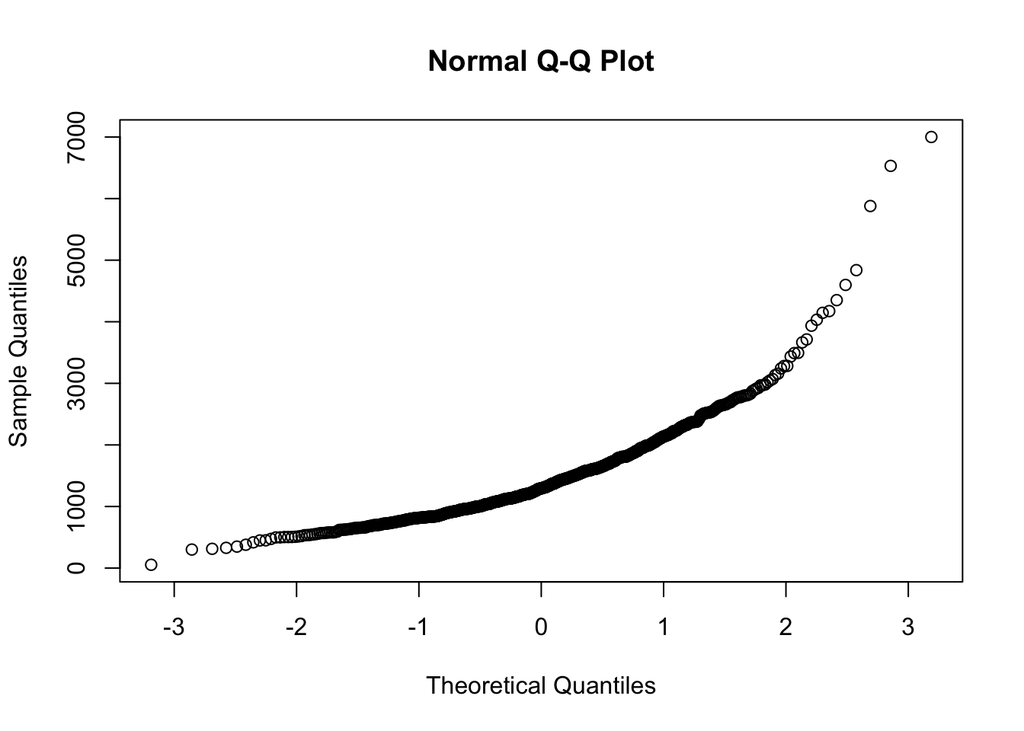

```r
qqnorm (w3data1$RT)
```

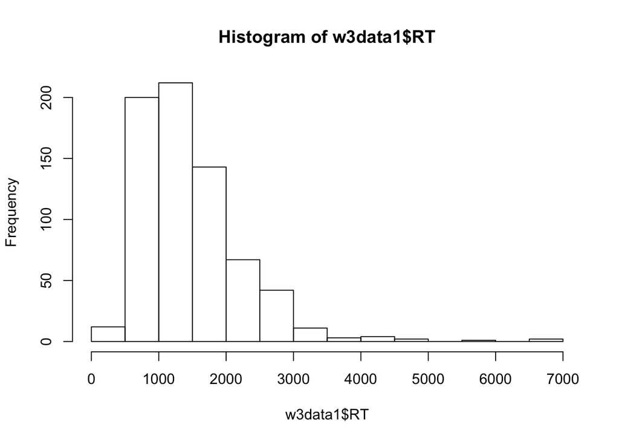

```r
hist (w3data1$RT)
```

That looks fairly skewed - we may want to either transform the data (via log transform) or build our LMM assuming our data comes from the Gamma distribution.

Let’s run a basic LMM first without transforming and choosing a different distribution:

```r
model1 <- lmer (RT ~ Condition + (1+Condition| Subject) + (1+Condition| Item), data=w3data1, REML=TRUE )
summary (model1)
```

```
## Linear mixed model fit by REML. t-tests use Satterthwaite's method [
## lmerModLmerTest]
## Formula: RT ~ Condition + (1 + Condition | Subject) + (1 + Condition |
##     Item)
##    Data: w3data1
##
## REML criterion at convergence: 11077.1
##
## Scaled residuals:
##     Min      1Q  Median      3Q     Max
## -2.0656 -0.5452 -0.1536  0.3564  7.0026
##
## Random effects:
##  Groups   Name          Variance Std.Dev. Corr
##  Subject  (Intercept)    74414   272.8
##           ConditionRare  16588   128.8    -0.01
##  Item     (Intercept)   110706   332.7
##           ConditionRare 125840   354.7    -0.21
##  Residual               364844   604.0
## Number of obs: 699, groups:  Subject, 50; Item, 28
##
## Fixed effects:
##               Estimate Std. Error      df t value Pr(>|t|)
## (Intercept)    1367.51      80.54   38.02  16.980   <2e-16 ***
## ConditionRare   200.10      83.17   25.80   2.406   0.0236 *
## ---
## Signif. codes:  0 '***' 0.001 '**' 0.01 '*' 0.05 '.' 0.1 ' ' 1
##
## Correlation of Fixed Effects:
##             (Intr)
## ConditionRr -0.289
```

We can see we have an effect of condition - the Intercept corresponds to our ‘Common’ condition and our ConditionRare estimate corresponds to the difference between our ‘Common’ and ‘Rare’ conditions. In other words, our ‘Rare’ condition words are about 200 msec. slower to respond to. That fits with the descriptives we calculated earlier.

Although the RT data themselves didn’t look normally distributed, what about the residuals?

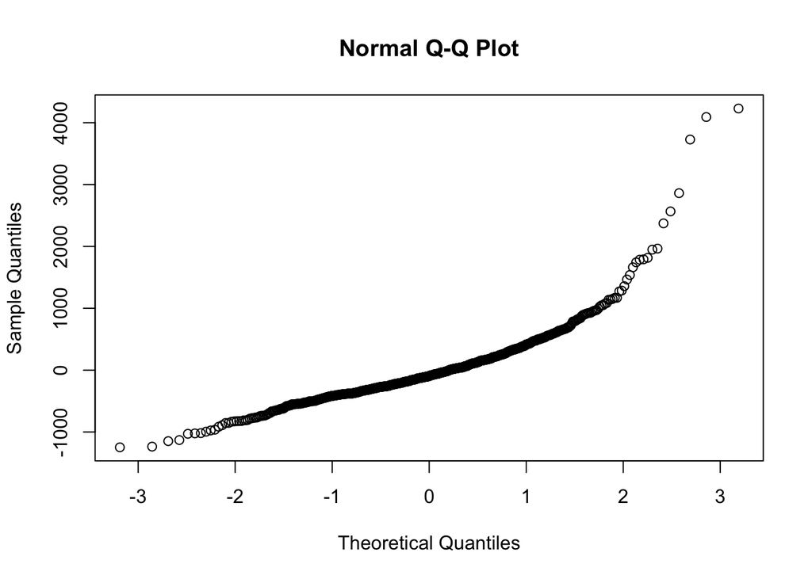

```r
qqnorm (residuals(model1))
```

OK, so these don’t look too normal either! We now have a couple of options - we could log transform our DV…

```r
model2 <- lmer (log(RT) ~ Condition + (1+Condition| Subject) + (1+Condition| Item), data=w3data1, REML=TRUE)
summary (model2)
```

```
## Linear mixed model fit by REML. t-tests use Satterthwaite's method [
## lmerModLmerTest]
## Formula:
## log(RT) ~ Condition + (1 + Condition | Subject) + (1 + Condition |
##     Item)
##    Data: w3data1
##
## REML criterion at convergence: 736.7
##
## Scaled residuals:
##     Min      1Q  Median      3Q     Max
## -5.5962 -0.5523 -0.0173  0.5480  3.7410
##
## Random effects:
##  Groups   Name          Variance Std.Dev. Corr
##  Subject  (Intercept)   0.056356 0.2374
##           ConditionRare 0.008226 0.0907   -0.76
##  Item     (Intercept)   0.072671 0.2696
##           ConditionRare 0.070676 0.2658   -0.45
##  Residual               0.124800 0.3533
## Number of obs: 699, groups:  Subject, 50; Item, 28
##
## Fixed effects:
##               Estimate Std. Error       df t value Pr(>|t|)
## (Intercept)    7.10880    0.06388 42.85829 111.291   <2e-16 ***
## ConditionRare  0.12612    0.05834 26.89753   2.162   0.0397 *
## ---
## Signif. codes:  0 '***' 0.001 '**' 0.01 '*' 0.05 '.' 0.1 ' ' 1
##
## Correlation of Fixed Effects:
##             (Intr)
## ConditionRr -0.493
```

The same finding holds - with the ‘Rare’ condition taking longer to read. Interpreting the estimates is harder though as they are log transformed… Do the residuals now look normally distributed?

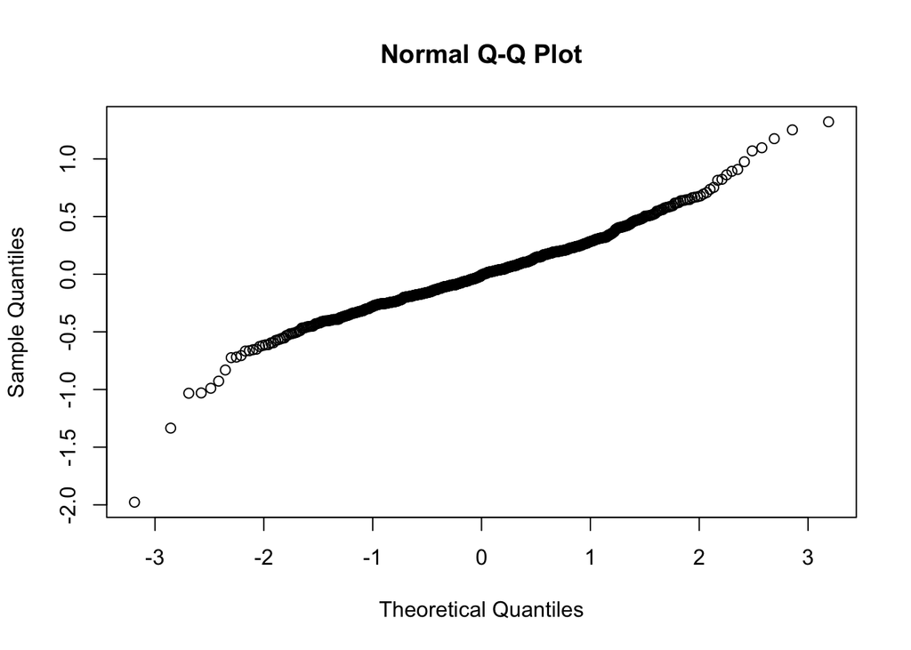

```r
qqnorm (residuals(model2))
```

This is looking a lot better than over the untransformed data. I think we’re justified in adopting model2 as our statistical model and analysing over the log transformed data.

# Q2

Within R, import the dataset w3data2. These data are from an experiment where we measured how long people spent looking at images that appeared on screen. The images depicted either positive, neutral, or negative scenes. This is our one factor with three levels. The design was repeated measures. Perform the appropriate LMM analysis and determine whether people spent a different amount of time looking at the positive relative to the negative images, and the neutral relative to the negative images.

```r
w3data2$Subject <- as.factor(w3data2$Subject)
w3data2$Item <- as.factor(w3data2$Item)
w3data2$Image <- as.factor(w3data2$Image)

#w3data2$Image <- relevel (w3data2$Image, ref=1)
```

Let’s generate some descriptives and visualise our data:

```r
describeBy(w3data2, group=w3data2$Image)
```

```
##
##  Descriptive statistics by group
## group: Negative
##          vars   n    mean     sd median trimmed    mad min  max range skew
## Subject*    1 350   25.50  14.45   25.5   25.50  18.53   1   50    49  0.0
## Item*       2 350   14.46   8.09   14.0   14.46  10.38   1   28    27  0.0
## RT          3 350 1369.97 658.13 1217.5 1293.62 553.75  54 4173  4119  1.2
## Image*      4 350    1.00   0.00    1.0    1.00   0.00   1    1     0  NaN
##          kurtosis    se
## Subject*    -1.21  0.77
## Item*       -1.21  0.43
## RT           1.80 35.18
## Image*        NaN  0.00
## --------------------------------------------------------
## group: Neutral
##          vars   n    mean     sd median trimmed    mad min  max range skew
## Subject*    1 350   25.50  14.45   25.5   25.50  18.53   1   50    49 0.00
## Item*       2 350   14.54   8.09   15.0   14.54  10.38   1   28    27 0.00
## RT          3 349 1562.79 864.18 1403.0 1452.18 673.10 329 7000  6671 2.27
## Image*      4 350    2.00   0.00    2.0    2.00   0.00   2    2     0  NaN
##          kurtosis    se
## Subject*    -1.21  0.77
## Item*       -1.21  0.43
## RT           8.99 46.26
## Image*        NaN  0.00
## --------------------------------------------------------
## group: Positive
##          vars   n    mean     sd median trimmed    mad min  max range skew
## Subject*    1 350   25.50  14.45   25.5   25.50  18.53   1   50    49 0.00
## Item*       2 350   14.50   8.09   14.5   14.50  11.12   1   28    27 0.00
## RT          3 339 1590.86 855.44 1377.0 1460.41 588.59 325 6223  5898 1.95
## Image*      4 350    3.00   0.00    3.0    3.00   0.00   3    3     0  NaN
##          kurtosis    se
## Subject*    -1.21  0.77
## Item*       -1.21  0.43
## RT           5.23 46.46
## Image*        NaN  0.00
```

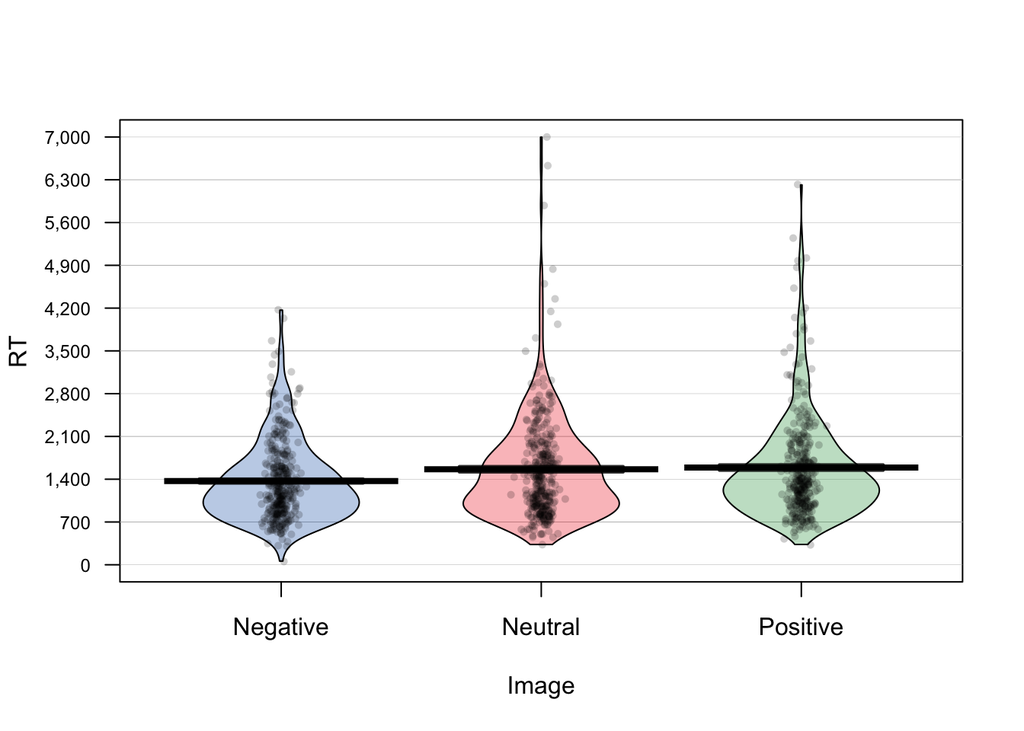

```r
pirateplot (formula=RT~Image, data=w3data2, inf.method="se", cex.axis=.75, theme=1)
```

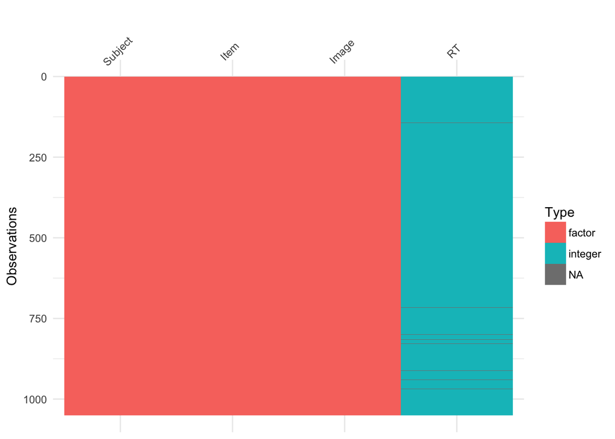

```r
vis_dat (w3data2)
```

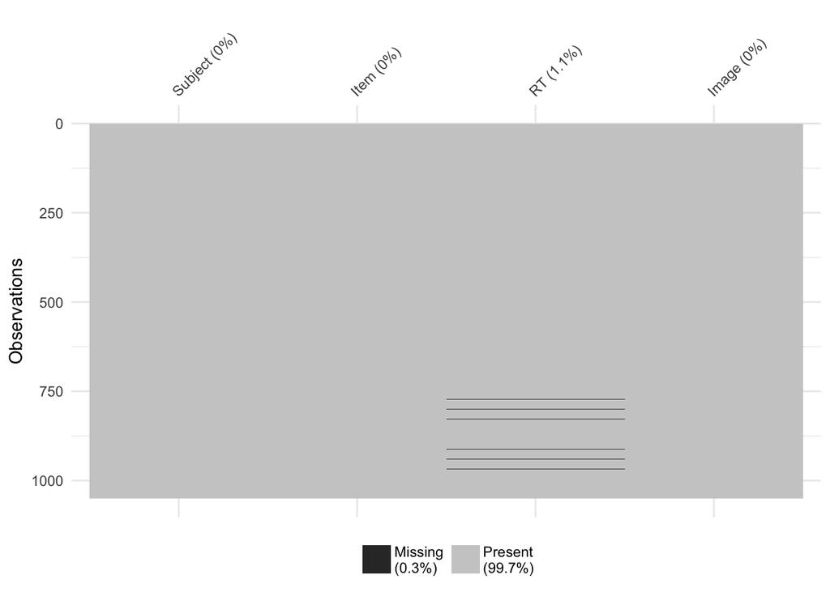

```r
vis_miss (w3data2)
```

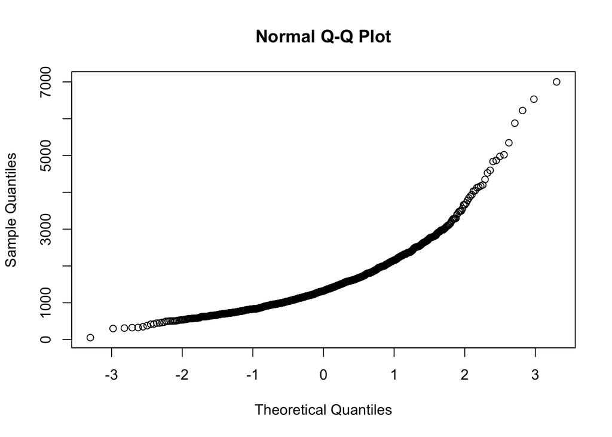

```r
qqnorm (w3data2$RT)
```

Again, we note that our DV is not normally distributed so we need to check our residuals.

```r
model1 <- lmer (RT ~ Image + (1+Image| Subject) + (1+Image| Item), data=w3data2, REML=TRUE)
summary (model1)
```

```
## Linear mixed model fit by REML. t-tests use Satterthwaite's method [
## lmerModLmerTest]
## Formula: RT ~ Image + (1 + Image | Subject) + (1 + Image | Item)
##    Data: w3data2
##
## REML criterion at convergence: 16492.5
##
## Scaled residuals:
##     Min      1Q  Median      3Q     Max
## -2.0189 -0.5608 -0.1722  0.3372  6.8963
##
## Random effects:
##  Groups   Name          Variance Std.Dev. Corr
##  Subject  (Intercept)    72803   269.82
##           ImageNeutral   12369   111.22    0.04
##           ImagePositive  27139   164.74    0.38 -0.91
##  Item     (Intercept)   108388   329.22
##           ImageNeutral  128010   357.79   -0.21
##           ImagePositive   6096    78.08    0.96 -0.48
##  Residual               391081   625.36
## Number of obs: 1038, groups:  Subject, 50; Item, 28
##
## Fixed effects:
##               Estimate Std. Error      df t value Pr(>|t|)
## (Intercept)    1368.08      80.28   39.77  17.041  < 2e-16 ***
## ImageNeutral    199.62      84.03   27.32   2.376 0.024784 *
## ImagePositive   212.19      55.37   57.96   3.832 0.000315 ***
## ---
## Signif. codes:  0 '***' 0.001 '**' 0.01 '*' 0.05 '.' 0.1 ' ' 1
##
## Correlation of Fixed Effects:
##             (Intr) ImgNtr
## ImageNeutrl -0.295
## ImagePositv  0.023  0.067
```

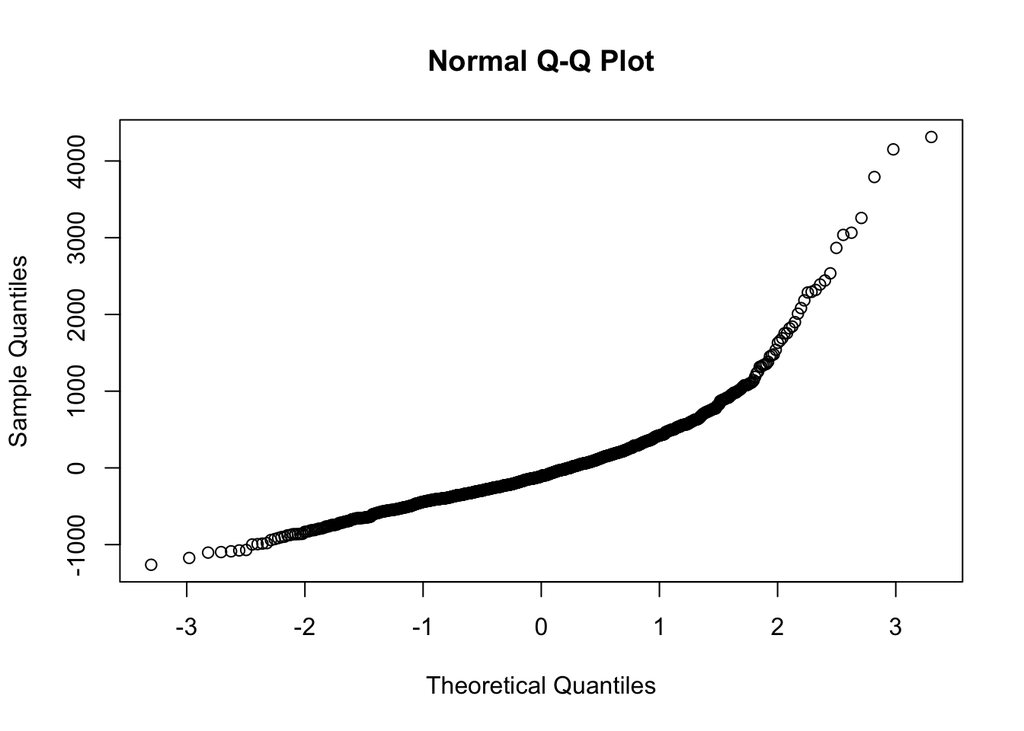

```r
qqnorm (residuals(model1))
```

```r
model2 <- lmer (log(RT) ~ Image + (1+Image| Subject) + (1+Image| Item), data=w3data2, REML=TRUE)
summary (model2)
```

```
## Linear mixed model fit by REML. t-tests use Satterthwaite's method [
## lmerModLmerTest]
## Formula: log(RT) ~ Image + (1 + Image | Subject) + (1 + Image | Item)
##    Data: w3data2
##
## REML criterion at convergence: 1024.2
##
## Scaled residuals:
##     Min      1Q  Median      3Q     Max
## -5.7652 -0.6323 -0.0621  0.5402  3.8502
##
## Random effects:
##  Groups   Name          Variance  Std.Dev. Corr
##  Subject  (Intercept)   0.0565024 0.23770
##           ImageNeutral  0.0092828 0.09635  -0.74
##           ImagePositive 0.0181080 0.13457  -0.43  0.47
##  Item     (Intercept)   0.0714191 0.26724
##           ImageNeutral  0.0736925 0.27146  -0.44
##           ImagePositive 0.0004923 0.02219  -0.99  0.29
##  Residual               0.1212256 0.34817
## Number of obs: 1038, groups:  Subject, 50; Item, 28
##
## Fixed effects:
##               Estimate Std. Error       df t value Pr(>|t|)
## (Intercept)    7.10941    0.06346 44.76973 112.023  < 2e-16 ***
## ImageNeutral   0.12574    0.05926 27.79887   2.122 0.042916 *
## ImagePositive  0.13998    0.03305 47.12836   4.236 0.000105 ***
## ---
## Signif. codes:  0 '***' 0.001 '**' 0.01 '*' 0.05 '.' 0.1 ' ' 1
##
## Correlation of Fixed Effects:
##             (Intr) ImgNtr
## ImageNeutrl -0.486
## ImagePositv -0.395  0.271
```

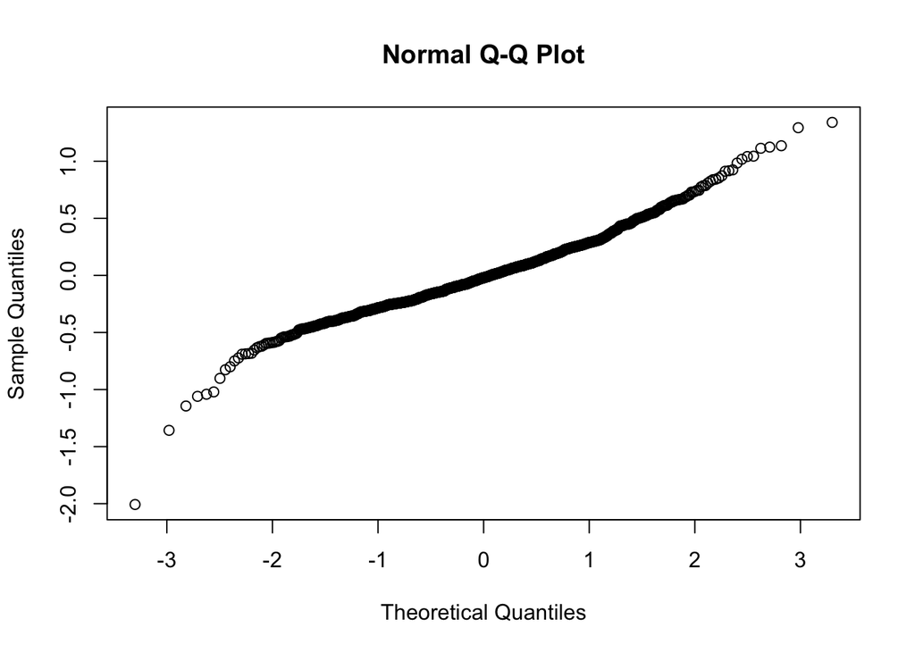

```r
qqnorm (residuals(model2))
```

OK, with log transformed data our residuals look a lot better. Again we find that the Neutral and Positive conditions differ from the Negative.

# Q3

Within R, import the dataset w2data3. These data are from a repeated measures experiment where participants had to respond to a target word. The target word always followed a prime word. Prime and Target are our two factors – each with two levels – Positive vs. Negative. We are interested in whether there is a priming effect (i.e., Positive target words responded to more quickly after Positive than after Negative Primes, and Negative target words responded to more quickly after Negative than after Positive Primes). Run the appropriate LMM to determine whether this is indeed correct.

First we need to create our factors:

```r
w3data3$Subject <- as.factor(w3data3$Subject)
w3data3$Item <- as.factor(w3data3$Item)
w3data3$Prime <- as.factor(w3data3$Prime)
w3data3$Target <- as.factor(w3data3$Target)
```

As it is a factorial experiment, we need to set up our contrast weightings for our two factors. This allows for easier intepretation of the paramester estimates - the intercept will correspond to the Grand Mean (i.e., the mean of our conditions).

```r
contrasts(w3data3$Prime) <- matrix (c(.5, -.5))
contrasts(w3data3$Target) <- matrix (c(.5, -.5))
```

```r
describeBy(w3data3$Time, group=list(w3data3$Prime, w3data3$Target))
```

```
##
##  Descriptive statistics by group
## : Negative
## : Negative
##    vars   n   mean     sd median trimmed    mad min  max range skew
## X1    1 283 321.44 166.88    288   297.6 134.92  86 1397  1311 2.14
##    kurtosis   se
## X1     7.75 9.92
## --------------------------------------------------------
## : Positive
## : Negative
##    vars   n   mean     sd median trimmed    mad min  max range skew
## X1    1 293 361.06 190.66    326  337.84 167.53  93 1283  1190 1.55
##    kurtosis    se
## X1     3.62 11.14
## --------------------------------------------------------
## : Negative
## : Positive
##    vars   n   mean     sd median trimmed    mad min  max range skew
## X1    1 290 375.88 219.36    323  347.55 175.69  82 1639  1557 1.57
##    kurtosis    se
## X1     3.97 12.88
## --------------------------------------------------------
## : Positive
## : Positive
##    vars   n   mean     sd median trimmed    mad min  max range skew
## X1    1 293 337.37 202.82    282  306.58 117.13  84 1802  1718 3.09
##    kurtosis    se
## X1     15.6 11.85
```

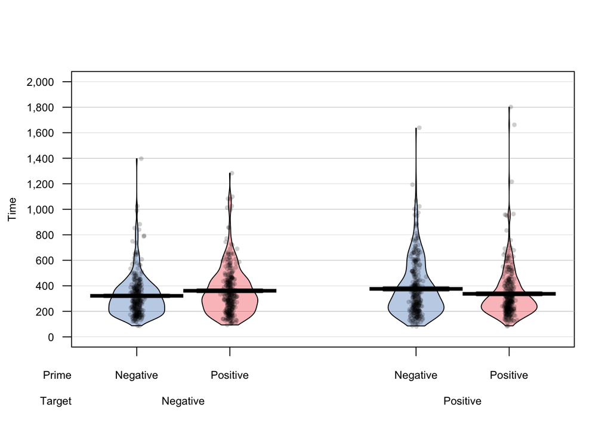

```r
pirateplot (formula=Time~Prime*Target, data=w3data3, inf.method="se", cex.axis=.75, theme=1, cex.names=.75, cex.lab=.75)
```

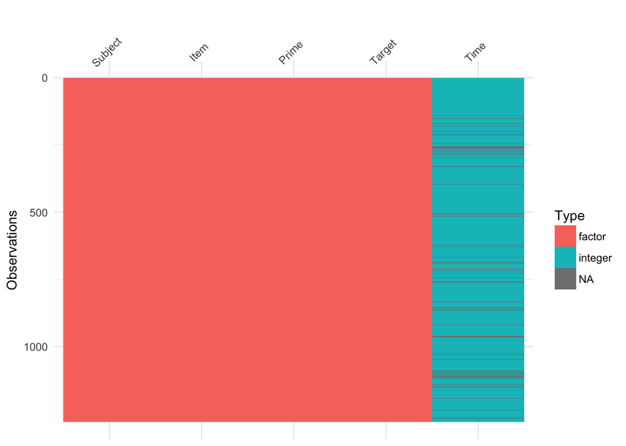

```r
vis_dat (w3data3)
```

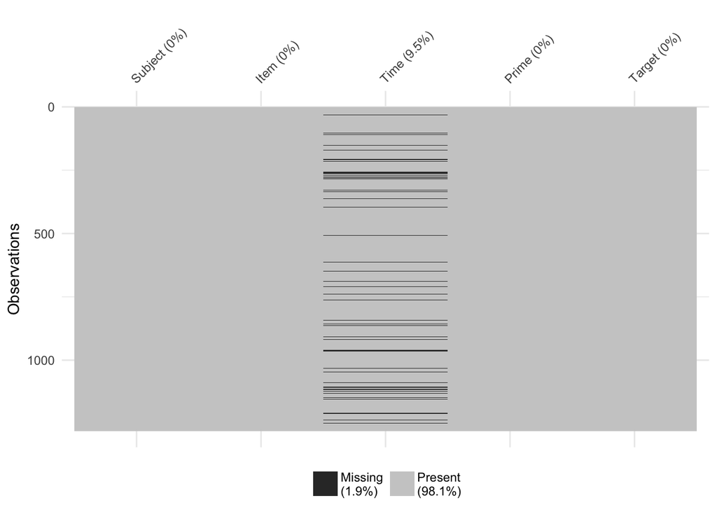

```r
vis_miss (w3data3)
```

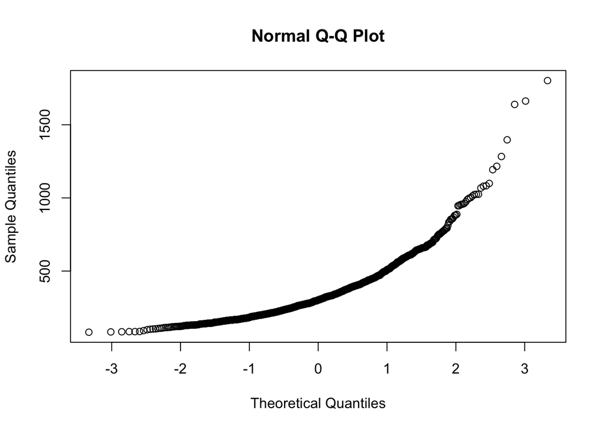

```r
qqnorm (w3data3$Time)
```

Note we have a little missing data - not a big deal, but something that you could report.

```r
model1 <- lmer (Time ~ Prime * Target + (1 + Prime * Target|Subject) + (1 + Prime * Target| Item), data=w3data3, REML=TRUE)
summary (model1)
```

```
## Linear mixed model fit by REML. t-tests use Satterthwaite's method [
## lmerModLmerTest]
## Formula: Time ~ Prime * Target + (1 + Prime * Target | Subject) + (1 +
##     Prime * Target | Item)
##    Data: w3data3
##
## REML criterion at convergence: 15336.5
##
## Scaled residuals:
##     Min      1Q  Median      3Q     Max
## -3.0636 -0.6074 -0.1822  0.4064  6.4657
##
## Random effects:
##  Groups   Name           Variance Std.Dev. Corr
##  Subject  (Intercept)     6091.3   78.05
##           Prime1           803.2   28.34    0.23
##           Target1         2165.8   46.54   -0.55 -0.94
##           Prime1:Target1   292.3   17.10   -0.57  0.67 -0.37
##  Item     (Intercept)     1439.1   37.94
##           Prime1           237.6   15.41   -0.77
##           Target1          136.4   11.68   -1.00  0.78
##           Prime1:Target1   402.8   20.07   -0.93  0.49  0.93
##  Residual                30083.9  173.45
## Number of obs: 1159, groups:  Subject, 40; Item, 32
##
## Fixed effects:
##                 Estimate Std. Error        df t value Pr(>|t|)
## (Intercept)    344.37358   14.95681  51.23332  23.025  < 2e-16 ***
## Prime1          -0.05088   11.48888  32.71103  -0.004 0.996494
## Target1        -15.26291   12.77283  47.68283  -1.195 0.238016
## Prime1:Target1 -77.24873   20.91635 178.03556  -3.693 0.000294 ***
## ---
## Signif. codes:  0 '***' 0.001 '**' 0.01 '*' 0.05 '.' 0.1 ' ' 1
##
## Correlation of Fixed Effects:
##             (Intr) Prime1 Targt1
## Prime1      -0.005
## Target1     -0.330 -0.178
## Prim1:Trgt1 -0.129  0.057  0.005
```

OK, our interaction is significant - we now need to run pairwise comparisons to figure out what condition(s) differs from what other condition(s). We need to use the lsmeans function from the emmeans package - let’s do the correction manually as only a couple of pairwise comparisons make theoretical sense. They are Positive/Positive vs Negative/Positive, and Negative/Negative vs Positive/Negative. These are the only pairs where we’re comparing the same target to the same target under the two different levels of our prime. So, we need to multiple by 2 the calculated p-values for these copmarisons to correct for familywise error.

```r
emmeans (model1, pairwise~Prime*Target, adjust="none")
```

```
## $emmeans
##  Prime    Target     emmean       SE    df lower.CL upper.CL
##  Negative Negative 317.4045 15.25020 32.18 286.3477 348.4613
##  Positive Negative 356.0797 17.30476 38.17 321.0532 391.1063
##  Negative Positive 371.2918 20.43652 41.58 330.0369 412.5467
##  Positive Positive 332.7183 18.77931 40.69 294.7840 370.6526
##
## Degrees-of-freedom method: kenward-roger
## Confidence level used: 0.95
##
## $contrasts
##  contrast                               estimate       SE    df t.ratio
##  Negative,Negative - Positive,Negative -38.67524 16.02756 20.22  -2.413
##  Negative,Negative - Negative,Positive -53.88728 16.60137 21.58  -3.246
##  Negative,Negative - Positive,Positive -15.31379 15.65484 19.18  -0.978
##  Positive,Negative - Negative,Positive -15.21204 18.66205 26.07  -0.815
##  Positive,Negative - Positive,Positive  23.36145 16.50844 21.66   1.415
##  Negative,Positive - Positive,Positive  38.57349 15.13049 18.03   2.549
##  p.value
##   0.0254
##   0.0038
##   0.3401
##   0.4224
##   0.1713
##   0.0201
```

What do the residuals look like?

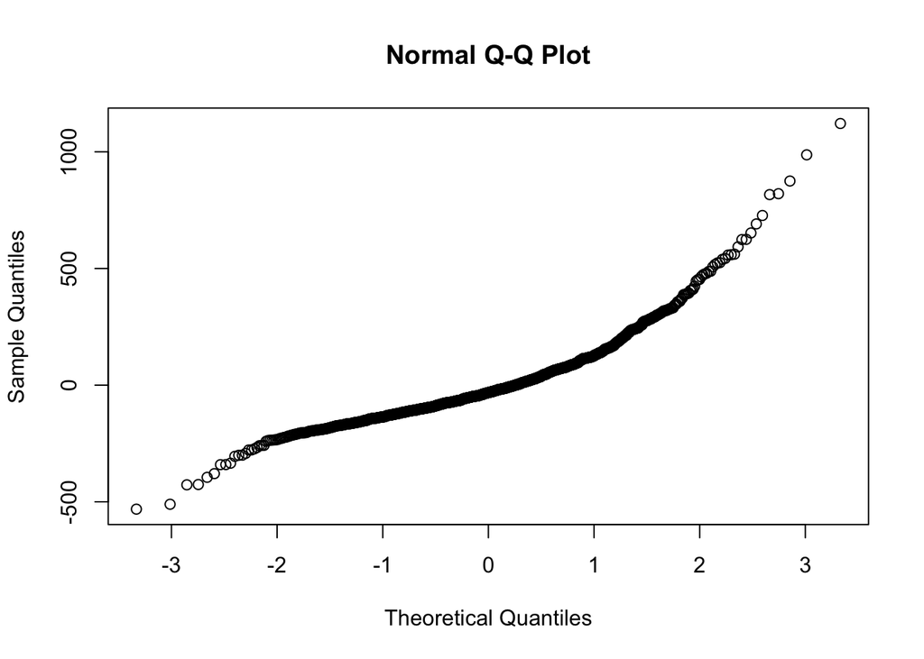

```r
qqnorm (residuals(model1))
```

How about we try building a model under the Gamma distribution?

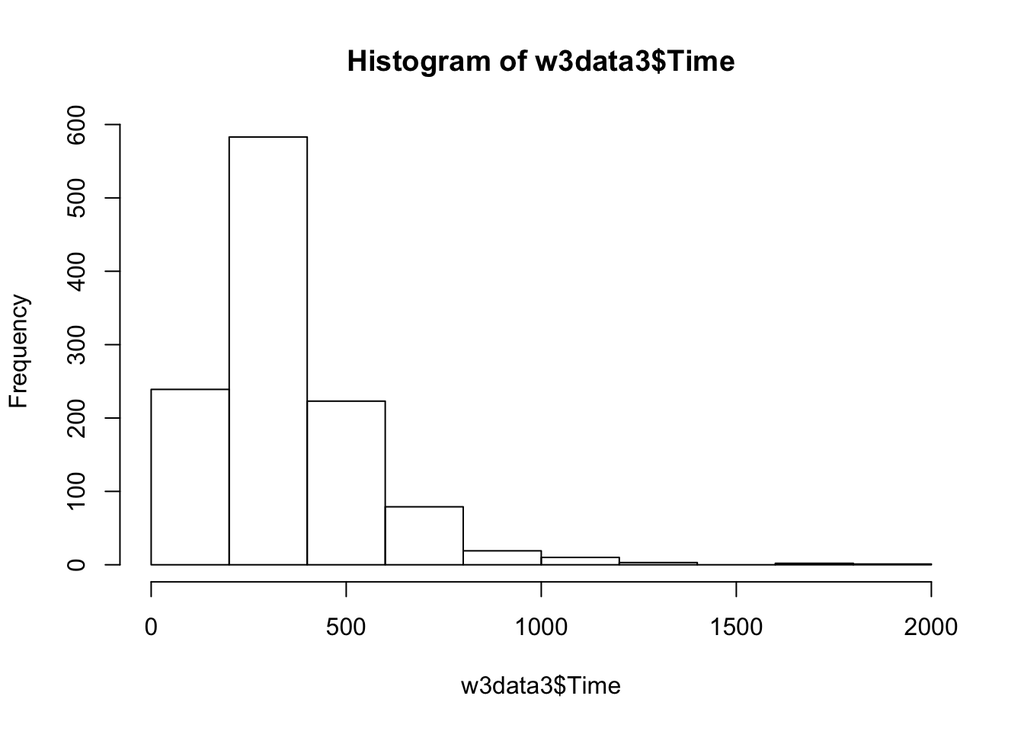

```r
hist (w3data3$Time)
```

```r
model3 <- glmer (Time ~ Prime * Target + (1 + Prime * Target|Subject) + (1 + Prime * Target| Item), data=w3data3, family=Gamma(link="log"))
summary (model3)
```

```
## Generalized linear mixed model fit by maximum likelihood (Laplace
##   Approximation) [glmerMod]
##  Family: Gamma  ( log )
## Formula: Time ~ Prime * Target + (1 + Prime * Target | Subject) + (1 +
##     Prime * Target | Item)
##    Data: w3data3
##
##      AIC      BIC   logLik deviance df.resid
##  14786.0  14912.4  -7368.0  14736.0     1134
##
## Scaled residuals:
##     Min      1Q  Median      3Q     Max
## -1.7032 -0.6689 -0.1799  0.4830  4.3620
##
## Random effects:
##  Groups   Name           Variance Std.Dev. Corr
##  Subject  (Intercept)    0.028737 0.16952
##           Prime1         0.013968 0.11818   0.24
##           Target1        0.016513 0.12850  -0.06 -0.55
##           Prime1:Target1 0.029607 0.17207  -0.26 -0.05 -0.22
##  Item     (Intercept)    0.008813 0.09388
##           Prime1         0.013631 0.11675  -0.24
##           Target1        0.002739 0.05233  -0.50 -0.14
##           Prime1:Target1 0.028285 0.16818  -0.01 -0.01 -0.72
##  Residual                0.207344 0.45535
## Number of obs: 1159, groups:  Subject, 40; Item, 32
##
## Fixed effects:
##                 Estimate Std. Error t value Pr(>|z|)
## (Intercept)     5.769049   0.056740 101.675   <2e-16 ***
## Prime1         -0.005105   0.046860  -0.109   0.9132
## Target1        -0.036007   0.039978  -0.901   0.3678
## Prime1:Target1 -0.188104   0.074047  -2.540   0.0111 *
## ---
## Signif. codes:  0 '***' 0.001 '**' 0.01 '*' 0.05 '.' 0.1 ' ' 1
##
## Correlation of Fixed Effects:
##             (Intr) Prime1 Targt1
## Prime1       0.054
## Target1     -0.151 -0.285
## Prim1:Trgt1 -0.145 -0.002 -0.207
## convergence code: 0
## Model failed to converge with max|grad| = 0.004467 (tol = 0.001, component 1)
```

Notice at the top we get an error - although we have parameter estimates, they may not be quite accurate. We can start by simplying our reandom effects structure - we drop the interaction term from the Item random effect and use only additive effects of Prime and Target here. Remember, Prime*Target is the same as Prime + Target + Prime:Target - where the final term is the interaction effect.

```r
model4 <- glmer (Time ~ Prime * Target + (1 + Prime * Target|Subject) + (1 + Prime + Target| Item), data=w3data3, family=Gamma(link="log"))
summary (model4)
```

```
## Generalized linear mixed model fit by maximum likelihood (Laplace
##   Approximation) [glmerMod]
##  Family: Gamma  ( log )
## Formula: Time ~ Prime * Target + (1 + Prime * Target | Subject) + (1 +
##     Prime + Target | Item)
##    Data: w3data3
##
##      AIC      BIC   logLik deviance df.resid
##  14781.0  14887.2  -7369.5  14739.0     1138
##
## Scaled residuals:
##     Min      1Q  Median      3Q     Max
## -1.6926 -0.6691 -0.1814  0.4761  4.3549
##
## Random effects:
##  Groups   Name           Variance Std.Dev. Corr
##  Subject  (Intercept)    0.028764 0.16960
##           Prime1         0.014350 0.11979   0.23
##           Target1        0.016682 0.12916  -0.06 -0.56
##           Prime1:Target1 0.029342 0.17130  -0.27 -0.04 -0.23
##  Item     (Intercept)    0.008793 0.09377
##           Prime1         0.013340 0.11550  -0.24
##           Target1        0.002591 0.05090  -0.50 -0.17
##  Residual                0.209045 0.45721
## Number of obs: 1159, groups:  Subject, 40; Item, 32
##
## Fixed effects:
##                 Estimate Std. Error t value Pr(>|z|)
## (Intercept)     5.771640   0.056603 101.968  < 2e-16 ***
## Prime1         -0.008633   0.046839  -0.184  0.85377
## Target1        -0.035560   0.039859  -0.892  0.37231
## Prime1:Target1 -0.189350   0.061171  -3.095  0.00197 **
## ---
## Signif. codes:  0 '***' 0.001 '**' 0.01 '*' 0.05 '.' 0.1 ' ' 1
##
## Correlation of Fixed Effects:
##             (Intr) Prime1 Targt1
## Prime1       0.053
## Target1     -0.153 -0.300
## Prim1:Trgt1 -0.169 -0.002 -0.080
## convergence code: 0
## Model failed to converge with max|grad| = 0.00449121 (tol = 0.001, component 1)
```

OK, so we have a convergence error here too - let’s simplify further - now by dropping the interaction term from the Subject random effect too:

```r
model5 <- glmer (Time ~ Prime * Target + (1 + Prime + Target|Subject) + (1 + Prime + Target| Item), data=w3data3, family=Gamma(link="log"))
summary (model5)
```

```
## Generalized linear mixed model fit by maximum likelihood (Laplace
##   Approximation) [glmerMod]
##  Family: Gamma  ( log )
## Formula: Time ~ Prime * Target + (1 + Prime + Target | Subject) + (1 +
##     Prime + Target | Item)
##    Data: w3data3
##
##      AIC      BIC   logLik deviance df.resid
##  14776.4  14862.3  -7371.2  14742.4     1142
##
## Scaled residuals:
##     Min      1Q  Median      3Q     Max
## -1.6858 -0.6643 -0.1781  0.4615  4.3045
##
## Random effects:
##  Groups   Name        Variance Std.Dev. Corr
##  Subject  (Intercept) 0.028914 0.17004
##           Prime1      0.014506 0.12044   0.24
##           Target1     0.016927 0.13010  -0.07 -0.56
##  Item     (Intercept) 0.008832 0.09398
##           Prime1      0.013557 0.11644  -0.23
##           Target1     0.002753 0.05247  -0.49 -0.17
##  Residual             0.210909 0.45925
## Number of obs: 1159, groups:  Subject, 40; Item, 32
##
## Fixed effects:
##                Estimate Std. Error t value Pr(>|z|)
## (Intercept)     5.77306    0.05660 101.993  < 2e-16 ***
## Prime1         -0.01077    0.04708  -0.229    0.819
## Target1        -0.03526    0.04017  -0.878    0.380
## Prime1:Target1 -0.20136    0.04934  -4.081 4.48e-05 ***
## ---
## Signif. codes:  0 '***' 0.001 '**' 0.01 '*' 0.05 '.' 0.1 ' ' 1
##
## Correlation of Fixed Effects:
##             (Intr) Prime1 Targt1
## Prime1       0.059
## Target1     -0.154 -0.300
## Prim1:Trgt1  0.004  0.008  0.009
## convergence code: 0
## Model failed to converge with max|grad| = 0.00191226 (tol = 0.001, component 1)
```

After a few iterations, we end up with this model:

```r
model6 <- glmer (Time ~ Prime * Target + (1 + Prime |Subject) + (1 + Prime | Item), data=w3data3, family=Gamma(link="log"))
summary (model6)
```

```
## Generalized linear mixed model fit by maximum likelihood (Laplace
##   Approximation) [glmerMod]
##  Family: Gamma  ( log )
## Formula: Time ~ Prime * Target + (1 + Prime | Subject) + (1 + Prime |
##     Item)
##    Data: w3data3
##
##      AIC      BIC   logLik deviance df.resid
##  14779.7  14835.3  -7378.9  14757.7     1148
##
## Scaled residuals:
##     Min      1Q  Median      3Q     Max
## -1.6451 -0.6641 -0.1941  0.4585  4.5551
##
## Random effects:
##  Groups   Name        Variance Std.Dev. Corr
##  Subject  (Intercept) 0.02954  0.17187
##           Prime1      0.01540  0.12408  0.25
##  Item     (Intercept) 0.00931  0.09649
##           Prime1      0.01382  0.11756  -0.21
##  Residual             0.21703  0.46586
## Number of obs: 1159, groups:  Subject, 40; Item, 32
##
## Fixed effects:
##                Estimate Std. Error t value Pr(>|z|)
## (Intercept)     5.78137    0.05696 101.504  < 2e-16 ***
## Prime1         -0.01122    0.04748  -0.236   0.8132
## Target1        -0.04123    0.02498  -1.650   0.0989 .
## Prime1:Target1 -0.21206    0.04983  -4.256 2.08e-05 ***
## ---
## Signif. codes:  0 '***' 0.001 '**' 0.01 '*' 0.05 '.' 0.1 ' ' 1
##
## Correlation of Fixed Effects:
##             (Intr) Prime1 Targt1
## Prime1      0.072
## Target1     0.004  0.004
## Prim1:Trgt1 0.002  0.004  0.010
```

This model converges and reveals a significant interaction - correcting the familywise error rate suggests we might have a power problem as neither of the key pairwise comparisons is significant - .058 and .153 Having said that, our data don’t perfectly follow the Gamma distribution so this is going to be a judgement call. It is probably worth also analysing using log transformed data and then checking the residuals of that.

```r
emmeans (model6, pairwise~Prime*Target, adjust="none")
```

```
## $emmeans
##  Prime    Target     emmean         SE  df asymp.LCL asymp.UCL
##  Negative Negative 5.702130 0.06580082 Inf  5.573163  5.831097
##  Positive Negative 5.819374 0.06262981 Inf  5.696622  5.942126
##  Negative Positive 5.849383 0.06561277 Inf  5.720785  5.977982
##  Positive Positive 5.754573 0.06259189 Inf  5.631895  5.877251
##
## Results are given on the log (not the response) scale.
## Confidence level used: 0.95
##
## $contrasts
##  contrast                                 estimate         SE  df z.ratio
##  Negative,Negative - Positive,Negative -0.11724451 0.05370291 Inf  -2.183
##  Negative,Negative - Negative,Positive -0.14725356 0.03546529 Inf  -4.152
##  Negative,Negative - Positive,Positive -0.05244297 0.05374243 Inf  -0.976
##  Positive,Negative - Negative,Positive -0.03000905 0.05355092 Inf  -0.560
##  Positive,Negative - Positive,Positive  0.06480154 0.03509560 Inf   1.846
##  Negative,Positive - Positive,Positive  0.09481059 0.05352822 Inf   1.771
##  p.value
##   0.0290
##   <.0001
##   0.3292
##   0.5752
##   0.0648
##   0.0765
##
## Results are given on the log (not the response) scale.
```

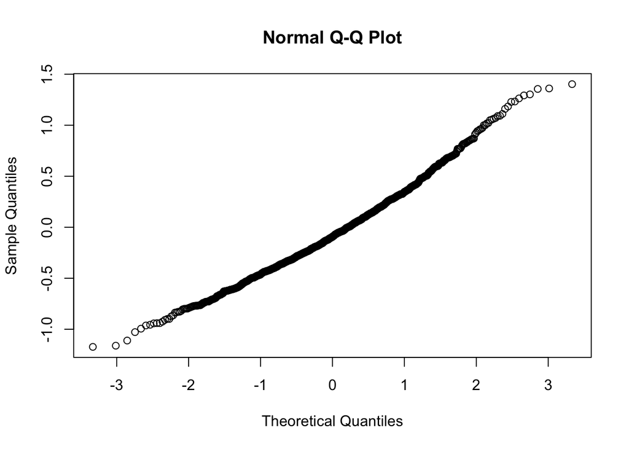

```r
qqnorm (residuals(model6))
```

Indeed, log transformed looks slighlty better in terms of normality of the residuals (although there’s really not much in it):

```r
model7 <- lmer (log(Time) ~ Prime * Target + (1 + Prime * Target|Subject) + (1 + Prime * Target| Item), data=w3data3, REML=TRUE)
summary (model7)
```

```
## Linear mixed model fit by REML. t-tests use Satterthwaite's method [
## lmerModLmerTest]
## Formula: log(Time) ~ Prime * Target + (1 + Prime * Target | Subject) +
##     (1 + Prime * Target | Item)
##    Data: w3data3
##
## REML criterion at convergence: 1509.6
##
## Scaled residuals:
##     Min      1Q  Median      3Q     Max
## -2.8696 -0.6773 -0.0318  0.6279  3.1848
##
## Random effects:
##  Groups   Name           Variance  Std.Dev. Corr
##  Subject  (Intercept)    0.0472876 0.21746
##           Prime1         0.0061354 0.07833   0.64
##           Target1        0.0054936 0.07412  -0.17 -0.87
##           Prime1:Target1 0.0078593 0.08865  -1.00 -0.69  0.25
##  Item     (Intercept)    0.0090350 0.09505
##           Prime1         0.0015000 0.03873  -0.95
##           Target1        0.0004729 0.02175  -0.96  0.81
##           Prime1:Target1 0.0001890 0.01375   0.15  0.18 -0.42
##  Residual                0.1901889 0.43611
## Number of obs: 1159, groups:  Subject, 40; Item, 32
##
## Fixed effects:
##                  Estimate Std. Error         df t value Pr(>|t|)
## (Intercept)      5.711416   0.040396  49.590781 141.385  < 2e-16 ***
## Prime1          -0.009569   0.029333  40.142804  -0.326  0.74595
## Target1         -0.026724   0.028531  53.437917  -0.937  0.35316
## Prime1:Target1  -0.181359   0.053287 169.580473  -3.403  0.00083 ***
## ---
## Signif. codes:  0 '***' 0.001 '**' 0.01 '*' 0.05 '.' 0.1 ' ' 1
##
## Correlation of Fixed Effects:
##             (Intr) Prime1 Targt1
## Prime1       0.140
## Target1     -0.112 -0.121
## Prim1:Trgt1 -0.218 -0.070  0.034
```

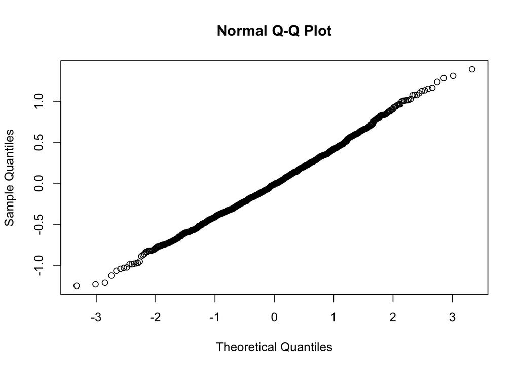

```r
qqnorm (residuals(model7))
```

Those residuals look pretty nice - clearly normally distributed so we should adopt model7 as our model. Let’s run the pairwise comparisons using emmeans - we need to remember to correct for the familywise error manually.

```r
emmeans (model7, pairwise~Prime*Target, adjust="none")
```

```
## $emmeans
##  Prime    Target     emmean         SE    df lower.CL upper.CL
##  Negative Negative 5.647930 0.04441483 36.22 5.557872 5.737988
##  Positive Negative 5.748179 0.04670675 39.84 5.653769 5.842588
##  Negative Positive 5.765333 0.05339449 40.29 5.657443 5.873224
##  Positive Positive 5.684223 0.04388192 38.92 5.595458 5.772988
##
## Degrees-of-freedom method: kenward-roger
## Results are given on the log (not the response) scale.
## Confidence level used: 0.95
##
## $contrasts
##  contrast                                 estimate         SE    df
##  Negative,Negative - Positive,Negative -0.10024844 0.03835972 18.30
##  Negative,Negative - Negative,Positive -0.11740301 0.03982981 19.77
##  Negative,Negative - Positive,Positive -0.03629264 0.03854249 18.42
##  Positive,Negative - Negative,Positive -0.01715456 0.04339322 23.37
##  Positive,Negative - Positive,Positive  0.06395580 0.03848619 18.84
##  Negative,Positive - Positive,Positive  0.08111036 0.04109253 21.23
##  t.ratio p.value
##   -2.613  0.0174
##   -2.948  0.0080
##   -0.942  0.3586
##   -0.395  0.6962
##    1.662  0.1131
##    1.974  0.0616
##
## Results are given on the log (not the response) scale.
```

We see the interaction is being driven by the Negative,Negative - Positive, Negative difference. This is the same we found with with the comparisons using the glmer function and the Gamma distribution.